# Efficient simulations in R

2021-06-24

## Motivation

Being able to code up efficient simulations is one of the most useful skills that you can develop as a social (data) scientist. Unfortunately, it’s also something that’s rarely taught in universities or textbooks.[^1] This post will cover some general principles that I’ve adopted for writing fast simulation code in R.

Now, I should clarify that the type of simulations that I, personally, am most interested in are related to *econometrics*. For example, Monte Carlo experiments to better understand when a particular estimator or regression specification does well (or poorly). The guidelines here should be considered accordingly and might not map well on to other domains (e.g. agent-based models or numerical computation).

## Our example: Interaction effects in panel models

I’m going to illustrate by replicating a simulation result in a paper that I really like: “Interaction effects in econometrics” by [Balli & Sørensen (2012)](https://www.uh.edu/~bsorense/Interaction_EE.pdf) (hereafter, **BS12**).

BS12 does various things, but one result in particular has had a big impact on my own research. They show that empirical researchers working with panel data are well advised to demean any (continuous) variables that are going to be interacted in a regression. That is, rather than estimating the model in “level” terms…

$$Y_{it} = \mu_i + \beta_1X1_{it} + \beta_2X2_{it} + \beta_3X1_{it} \cdot X2_{it} + \epsilon_{it}$$
… you should estimate the “demeaned” version instead[^2]

$$Y_{it} = \beta_0 + \beta_1 (X1_{it} - \overline{X1}_{i.}) + \beta_2 (X2_{it} - \overline{X2}_{i.}) + \beta_3(X1_{it} - \overline{X1}_{i.}) \cdot (X2_{it} - \overline{X2}_{i.}) + \epsilon_{it}$$
Here, $\overline{X1}_{i.}$ refers to mean value of variable $X1$ (e.g. GDP over time) for unit $i$ (e.g. country).

We’ll get to the simulations in a second, but BS12 describe the reasons for their recommendation in very intuitive terms. The super short version — again, you really should read the paper — is that the level model can pick up spurious trends in the case of varying slopes. The implications of this insight are fairly profound… if for no other reason that *so* many applied econometrics papers employ interaction terms in a panel setting.[^3]

Okay, so a potentially big deal. But let’s see a simulation and thereby get the ball rolling for this post. I’m going to run a simulation experiment that exactly mimics one in BS12 (see Table 3). We’ll create a fake dataset where the true interaction is ZERO. However, the slope coefficient of one of the parent terms varies by unit (here: country). If BS12 is right, then including an interaction term in our model could accidentally result in a spurious, non-zero coefficient on this interaction term. The exact model is

$$y_{it} = \alpha + x_{1,it} + 1.5x_{2,it} + \epsilon_{it}$$
### Data generating function

It will prove convenient for me to create a function that generates an instance of the experimental dataset — i.e. corresponding to one simulation run — which is what you see in the code below. The exact details are not especially important. (I’m going to coerce the return object into a **data.table** instead of standard data frame, but I’ll get back to that later.) For now, just remember that the coefficient on any interaction term should be zero by design. I’ll preview the resulting dataset at the end of the code.

```r
library(data.table)

## Convenience function for generating our experimental panel data. Takes a
## single argument: `sims` (i.e. how many simulation runs to do we want; defaults
## to 1).
gen_data = function(sims=1) {

  ## Total time periods in the the panel = 500
  tt = 500

  sim = rep(rep(1:sims, each = 10), times = 2) ## Repeat twice b/c we have two countries

  ## x1 covariates
  x1_A = 1 + rnorm(tt*sims, 0, 1)
  x1_B = 1/4 + rnorm(tt*sims, 0, 1)

  ## Add second, nested x2 covariates for each country
  x2_A = 1 + x1_A + rnorm(tt*sims, 0, 1)
  x2_B = 1 + x1_B + rnorm(tt*sims, 0, 1)

  ## Outcomes (notice different slope coefs for x2_A and x2_B)
  y_A = x1_A + 1*x2_A + rnorm(tt*sims, 0, 1)
  y_B = x1_B + 2*x2_B + rnorm(tt*sims, 0, 1)

  ## Combine in a data table (basically just an enhanced data frame)
  dat =
    data.table(
      sim,
      id = as.factor(c(rep('A', length(x1_A)), rep('B', length(x1_B)))),
      x1 = c(x1_A, x1_B),
      x2 = c(x2_A, x2_B),
      y = c(y_A, y_B)
      )

  ## Demeaned covariates (grouped by country and simulation)
  dat[,
      `:=` (x1_dmean = x1 - mean(x1),
            x2_dmean = x2 - mean(x2)),
      by = .(sim, id)][]

  ## Optional set order i.t.o sims
  setorder(dat, sim)

  return(dat)
}
## Generate an instance of the data (using the default arguments)
set.seed(123)
d = gen_data()
d
```

```
##       sim id            x1         x2          y    x1_dmean    x2_dmean
##    1:   1  A  0.4395243534  0.4437256  0.3716463 -0.59506609 -1.61706557
##    2:   1  A  0.7698225105  0.7298675  1.7366279 -0.26476794 -1.33092373
##    3:   1  A  2.5587083141  3.5407281  5.5578472  1.52411787  1.47993688
##    4:   1  A  1.0705083914  1.9383333  4.2280693  0.03591794 -0.12245794
##    5:   1  A  1.1292877352 -0.4200550  0.8833686  0.09469729 -2.48084624
##   ---
##  996:   1  B  0.1600248030  1.2366685  3.6943280 -0.08764048 -0.06972657
##  997:   1  B  1.3205160368  2.5756808  6.0263720  1.07285075  1.26928576
##  998:   1  B -1.1011003857  0.1763464 -1.1775877 -1.34876567 -1.13004861
##  999:   1  B -0.2726166972  1.2642393  3.4448738 -0.52028198 -0.04215572
## 1000:   1  B  0.0008093222  0.5403238  1.9157509 -0.24685596 -0.76607128
```

Let’s run some regressions on one simulated draw of our dataset. Since this is a panel model, I’ll use the (incredible) **fixest** package to control for country (“id”) fixed-effects.

```r
library(fixest)

mod_level = feols(y ~ x1 * x2 | id, d)
mod_dmean = feols(y ~ x1_dmean * x2_dmean | id, d)
etable(mod_level, mod_dmean, se  = 'standard')
```

```
##                               mod_level          mod_dmean
## Dependent Var.:                       y                  y
##
## x1                    1.195*** (0.0650)
## x2                    1.638*** (0.0394)
## x1 x x2             -0.1373*** (0.0187)
## x1_dmean                                0.9544*** (0.0577)
## x2_dmean                                 1.556*** (0.0388)
## x1_dmean x x2_dmean                        0.0199 (0.0213)
## Fixed-Effects:      ------------------- ------------------
## id                                  Yes                Yes
## ___________________ ___________________ __________________
## S.E. type                      Standard           Standard
## Observations                      1,000              1,000
## R2                              0.86768            0.86062
## Within R2                       0.86761            0.86055
```

Well, there you have it. The “level” model spuriously yields a statistically significant coefficient on the interaction term. In comparison, the “demeaned” version avoids this trap and also appears to more closely estimated the parent term coefficients.

Okay. But to *really* be sure, we should repeat our simulation many times. (BS12 do it 20,000 times…) And, so, we finally get to the main purpose of this post.

## Principle 1: Trim the fat

**Subtitle: `lm.fit()` is your friend**

The first key principle for writing efficient simulation code is to trim the fat as much as possible. Even small differences start to add up once you’re repeating operations tens of thousands of times. For example, does it really make sense to use `fixest::feols()` for this example data? As much as I am a huge **fixest** stan, in this case I have to say… no. The package is optimised for high-dimensional fixed-effects, clustered errors, etc. Our toy dataset contains just one fixed-effect (comprising two levels) and we are ultimately only interested in extracting a single coefficient for our simulation. We don’t even need to save the standard errors. Most of **fixest**’s extra features are essentially wasted. We could probably do better just by using a simple `lm()` call and specifying the country fixed-effect (“id”) as a factor. However…

Even `lm()` objects contain quite a lot of information (and take extra steps) that we don’t need. We can simplify things even further by directly using the fitting function that `lm` calls underneath the hood. Specifically, the **`lm.fit()`** function. This requires a slightly different way of writing our regression model — closer to matrix form — but yields considerable speed gains. Here’s a benchmark to demonstrate.

```r
library(microbenchmark)

microbenchmark(
  feols  = feols(y ~ x1_dmean * x2_dmean | id, d),
  lm     = lm(y ~ x1_dmean * x2_dmean + id, d),
  lm.fit = lm.fit(cbind(1, d$x1_dmean, d$x2_dmean, d$x1_dmean*d$x2_dmean, as.factor(d$id)), d$y),
  times  = 2
  )
```

```
## Unit: microseconds
##    expr      min       lq     mean   median       uq      max neval cld
##   feols 4875.774 4875.774 5913.635 5913.635 6951.496 6951.496     2   b
##      lm 1049.682 1049.682 2177.765 2177.765 3305.849 3305.849     2  ab
##  lm.fit  105.668  105.668  130.130  130.130  154.592  154.592     2  a
```

```r
coef(lm.fit(cbind(1, d$x1_dmean, d$x2_dmean, d$x1_dmean*d$x2_dmean, d$id), d$y))
```

```
##          x1          x2          x3          x4          x5
##  3.16116857  0.95435281  1.55596182  0.01993248 -0.14977947
```

Thee output is less visually appealing, but we can see the interaction term coefficient of `0.01993247` in the order in which it appeared (i.e. “x4”). This is the key coefficient that we’ll be extracting in each of our simulation runs.[^5]

## Principle 2: Generate your data once

**Subtitle: It’s much quicker to generate one large dataset than many small ones.**

One common bottleneck I see in a lot of simulation code is generating a small dataset for each new run of a simulation. This is much less efficient that generating a single large dataset that you can either sample from during each iteration, or subset by a dedicated simulation ID. We’ll get to iteration next, but this second principle really stems from the same core idea: *[vectorisation](https://win-vector.com/2019/01/03/what-does-it-mean-to-write-vectorized-code-in-r/) in R is much faster than iteration*. Here’s a simple benchmark to illustrate, where we generate data for a 100 simulation runs. Note that the relative difference would keep growing as we added more simulations.

```r
microbenchmark(
  many_small = lapply(1:100, gen_data),
  one_big = gen_data(100),
  times = 2
)
```

```
## Unit: milliseconds
##        expr        min         lq       mean     median         uq        max
##  many_small 1439.73915 1439.73915 1716.90011 1716.90011 1994.06108 1994.06108
##     one_big   26.38005   26.38005   26.43527   26.43527   26.49048   26.49048
##  neval cld
##      2   b
##      2  a
```

## Principle 3: Try to avoid explicit iteration (even in parallel)

**Subtitle: Nest your simulations in a data.table or tibble**

The standard approach to coding up a simulation is to run everything as an iteration, either using a `for()` loop or an `lapply()` call. Experienced R programmers are probably reading this section right now and thinking, “Even better; run everything in parallel.” And it’s true. A Monte Carlo experiment like the one we’re doing here is ideally suited to parallel implementation, because each individual simulation run is independent. It’s a key reason why Monte Carlo experiments are such popular tools for teaching parallel programming concepts. ([Guilty as charged](https://grantmcdermott.com/ds4e/parallel.html#example-2-bootstrapping).)

But any type of explicit iteration — whether it is a `for()` loop or an `lapply()` call, whether it is run sequentially or in parallel — runs up against the same problem as we saw in Principle 2. Specifically, it is slower than vectorisation. So how can we run our simulations in vectorised fashion? Well, it turns out there is a pretty simple way that directly leverages Principle 2’s idea of generating one large dataset: We *nest* our simulations directly in our large **data.table** or **tibble**.

Hadley and Garret’s *R for Data Science* book has a nice [chapter](https://r4ds.had.co.nz/many-models.html) on model nesting, and then Vincent has a cool [blog post](http://www.arelbundock.com/posts/datatable_nesting/) replicating the same workflow with data.table. But, really, the core idea is pretty simple: We can use the advanced data structure and functionality of tibbles or data.tables to run our simulations as grouped operations (i.e. by simulation ID). Just like we can group a data frame and then collapse down to (say) mean values, we can also group a data frame and then run a regression on each subgroup.

Why would this be faster than explicit iteration? Well, basically it boils down to the fact that data.tables and tibbles provide an enhanced structure for returning complex objects (including list columns) and their grouped operations are highly optimised to run in (implicit) parallel at the C++ level.[^6] The internal code of **data.table**, in particular, is just so insanely optimised that trying to beat it with some explicit parallel loop is a [fools errand](https://grantmcdermott.com/ds4e/parallel.html#library-source-code).

Okay, so let’s see a benchmark. I’m going to compare three options for simulating 100 draws: 1) sequential iteration with `lapply()`, 2) explicit parallel iteration with `parallel::mclapply`, and 3) nested (implicit parallel) iteration. For the latter, I’ll just grouping my dataset by simulation ID and then leveraging data.table’s powerful `.SD` syntax.[^7] Note further than I’m just going to run regular `lm()` calls rather than `lm.fit()` — see Principle 1 — because I want to keep things simple and familiar.

```r
library(parallel) ## For parallel::mclapply

## Generate dataset with 1000 simulation draws
set.seed(123)
d = gen_data(100)

microbenchmark(
    sequential = lapply(1:max(d$sim),
                        function(i) coef(lm(y ~ x1 * x2 + id, d[sim==i]))['x1:x2']
                        ),

    parallel = mclapply(1:max(d$sim),
                        function(i) coef(lm(y ~ x1 * x2 + id, d[sim==i]))['x1:x2'],
                        mc.cores = detectCores()
                        ),

    nested = d[, coef(lm(y ~ x1 * x2 + id, .SD))['x1:x2'], by = sim],

    times = 2
    )
```

```
## Unit: milliseconds
##        expr       min        lq      mean    median       uq      max neval cld
##  sequential 157.12400 157.12400 165.81261 165.81261 174.5012 174.5012     2   b
##    parallel 135.93969 135.93969 138.11825 138.11825 140.2968 140.2968     2  ab
##      nested  88.24099  88.24099  96.88559  96.88559 105.5302 105.5302     2  a
```

Okay, not a huge difference between the three options for this small benchmark. But — trust me — the difference will grow for the full simulation where we’re comparing the level vs demeaned regressions with `lm.fit()`. There are also some other reasons why relying on **data.table** will help us here. For example, `parallel::mclapply()` relies on forking, which is only available on Linux or Mac. Sure, you could use a different package like **future.apply** to provide a parallel backend (PSOCK) for Windows, but that’s going to be a bit slower. Really, the bottom line is that we can outsource all of that parallel overhead to **data.table** and it will automatically handle everything at the C(++) level. Winning.

## Putting it all together

Time to put everything together and run this thing. Like BS12, I’m going to simulate 20,000 runs. I’ll print the time it takes to complete the full simulation at the bottom.

```r
set.seed(123)

d = gen_data(2e4)

tic = Sys.time()
sims =
  d[,
    .(level = coef(lm.fit(cbind(1, .SD$x1, .SD$x2, .SD$x1*.SD$x2, .SD$id),
                          .SD$y))['x4'],
      demeaned = coef(lm.fit(cbind(1, .SD$x1_dmean, .SD$x2_dmean, .SD$x1_dmean*.SD$x2_dmean, .SD$id),
                             .SD$y))['x4']),
    by = sim]
Sys.time() - tic
```

```
## Time difference of 3.661944 secs
```

And look at that. Just over 3 seconds to run the full 20k simulation!

All that hard work deserves a nice plot, don’t you think? Here we have replicated the key result in BS12, Table 3. Moral of the story: If you have an interaction effect in a panel setting (e.g. DiD), it’s always worth demeaning your terms and double check-checking that your results don’t change.

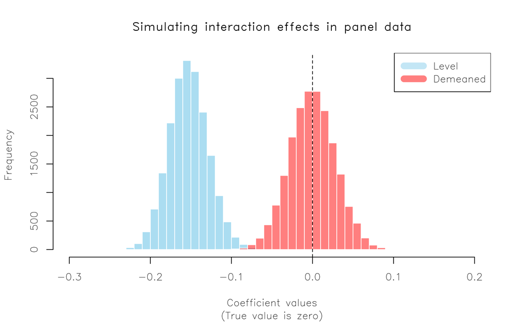

```r
par(family = 'HersheySans') ## Optional: Nice font for (base) plotting

hist(sims$level, col = scales::alpha('skyblue', .7), border=FALSE,
     main = 'Simulating interaction effects in panel data',
     xlim = c(-0.3, 0.2),
     xlab = 'Coefficient values',
     sub = '(True value is zero)')
hist(sims$demeaned, add=TRUE, col = scales::alpha('red', .5), border=FALSE)
abline(v = 0, lty = 2)
legend("topright", col = c(scales::alpha(c('skyblue', 'red'), .5)), lwd = 10,
       legend = c("Level", "Demeaned"))
```

[^1]: Ed Rubin and I are writing a [book](https://github.com/grantmcdermott/ds4e) that will attempt to fill this gap, among other things. Stay tuned!
[^2]: In their notation, BS12 only demean the interacted terms on $\beta_3$. But demeaning the parent terms on $\beta_1$ and $\beta_2$ is functionally equivalent and, as we shall see later, more convenient when writing the code since we can use R’s `*` expansion operator to concisely specify all of the terms.
[^3]: Got a difference-in-differences model uses twoway fixed-effects? Ya, that’s just an interaction term in a panel setting. In fact, the demeaning point that BS12 are making here and actually draw an explicit comparison to later in the paper, is equivalent to the argument that we should control for unit-specific time trends in DiD models. The paper includes additional simulations demonstrating this equivalence, but I don’t want to get sidetracked by that here.
[^4]: Another thing is that `lm.fit()` produces a much more limited, but leaner return object. So we’ll be taxing our computers’ memories less.
[^5]: You can also name the coefficients in the design matrix if you wanted to make it easier to reference by name. E.g. `coef(lm.fit(cbind('intercept' = 1, 'x1' = d$x1_dmean, 'x2' = d$x2_dmean, 'x1:x2' = d$x1_dmean*d$x2_dmean, 'id' = d$id), d$y))`.
[^6]: This basically all that vectorisation is; a loop return at the C(++) level.
[^7]: This will closely mimic a [related example](https://rdatatable.gitlab.io/data.table/articles/datatable-sd-usage.html#grouped-regression-1) in the data.table vignettes, which you can read more if you’re interested to learn more.